# Lab 10

Sarah Roffo

## Question 1

Use R package UScensus2010county to complete the following tasks: (20 pt.)

### Question 1(a)

Plot a map of New York counties using the plot function.

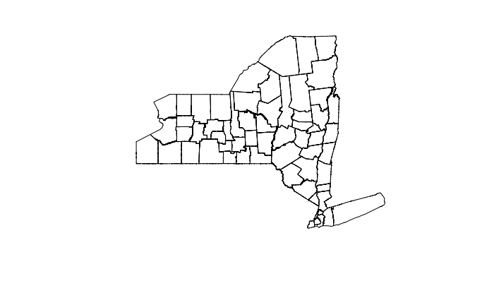

```r
library(UScensus2010)
if(!require(UScensus2010county)) install.county("osx")
library(UScensus2010county)
data(new_york.county10)
shp <- new_york.county10
plot(shp)
```

### Question 1(b)

Plot a map of New York counties using the qtm function.

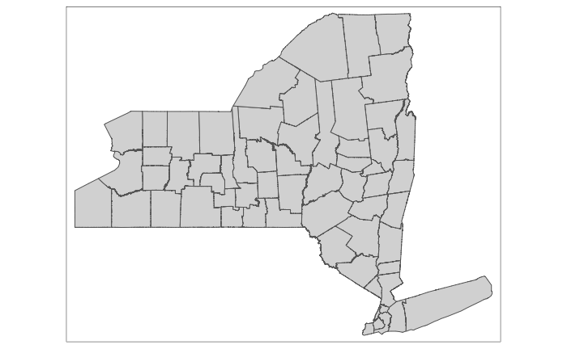

```r
library(tmap)
qtm(shp)
```

### Question 1(c)

How many counties in New York State?

```r
df1 <- shp@data
nrow(df1)
```

```
[1] 62
```

```r
print('There are 62 counties in New York State')
```

```
[1] "There are 62 counties in New York State"
```

### Question 1(d)

What’s the 3-digit fips code of Broome County?

```r
df1[df1$NAME10 == "Broome",]
```

|  | NAME10 | NAMELSAD10 | state | county | fips | P0010001 | P0020001 | P0020002 | P0020003 | P0020004 | P0020005 | P0020006 | P0030001 | P0030002 | P0030003 | P0030004 | P0030005 | P0030006 | P0030007 | P0030008 | P0040001 | P0040002 | P0040003 | P0050001 | P0050002 | P0050003 | P0050004 | P0050005 | P0050006 | … |
| --- | --- | --- | --- | --- | --- | --- | --- | --- | --- | --- | --- | --- | --- | --- | --- | --- | --- | --- | --- | --- | --- | --- | --- | --- | --- | --- | --- | --- | --- | --- |
| new_york.county10_0 | Broome | Broome County | 36 | 007 | 36007 | 200600 | 200600 | 0 | 0 | 0 | 0 | 200600 | 200600 | 176444 | 9614 | 396 | 7065 | 82 | 1912 | 5087 | 200600 | 193822 | 6778 | 200600 | 193822 | 173074 | 8850 | 328 | 7019 | … |

```r
print('The fips code of Broome County is 007 -- the last three digits of the fips column')
```

```
[1] "The fips code of Broome County is 007 -- the last three digits of the fips column"
```

### Question 1(e)

Compute descriptive statistics of the population column (P0010001), including total, minimum, maximum, mean, median, and skewness.

```r
df1 <- shp@data
min(df1$P0010001)
```

[output not shown]

```
[1] 4836
```

```r
max(df1$P0010001)
```

```
[1] 2504700
```

```r
mean(df1$P0010001)
```

```
[1] 312550
```

```r
median(df1$P0010001)
```

```
[1] 91301
```

```r
library(e1071)
skewness(df1$P0010001)
```

```
[1] 2.517639
```

### Question 1(f)

Create a histogram and a boxplot of the population.

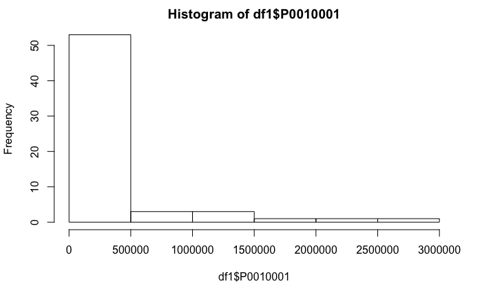

```r
hist(df1$P0010001)
```

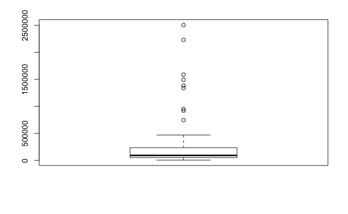

```r
boxplot(df1$P0010001)
```

## Question 2

Use R package UScensus2010tract to complete the following tasks: (20 pt.)

### Question 2(a)

Plot a map of New York census tracts using the plot function.

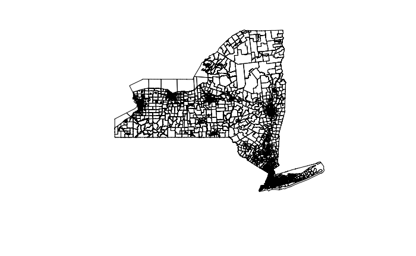

```r
library(UScensus2010)
if(!require(UScensus2010tract)) install.tract("osx")
library(UScensus2010tract)
data(new_york.tract10)
shp <- new_york.tract10
plot(shp)
```

### Question 2(b)

Compute the total population based on census tracts.

```r
df2 <- shp@data
pop <- df$P0010001
```

[output not shown]

[output not shown]

### Question 2(c)

Select all census tracts in Broome County and plot the map.

```r
plot(df2[df2$county == "007",])
```

[output not shown]

### Question 2(d)

What’s the total population of Broome County?

```r
df3 <- df2[df2$county == "007",]
total.pop <- sum(df3$P0010001)
sum(total.pop)
```

```
[1] 200600
```

```r
print('The total population of Broome County is 200,600.')
```

```
[1] "The total population of Broome County is 200,600."
```

### Question 2(e)

Create a histogram and a boxplot of population based on census tracts of Broome County.

[figure not shown]

[figure not shown]

### Question 2(f)

Select the first five columns of the shapefile of Broome County census tract; add a new population ratio column (= census tract population / county population); save the new shapefile to the hard drive.

[output not shown]

[output cut: 45 more lines]

## Question 3

Use R packages raster and ncdf4 to complete the following tasks: (20 pt.)

### Question 3(a)

Load the multi-band raster dataset “NDVI.nc” into R.

```r
NDVI_RB <- brick("NDVI.nc")
NDVI_RB <- brick("NDVI.nc")
NDVI_RB
```

```
class       : RasterBrick
dimensions  : 360, 720, 259200, 36  (nrow, ncol, ncell, nlayers)
resolution  : 0.5, 0.5  (x, y)
extent      : -180, 180, -90, 90  (xmin, xmax, ymin, ymax)
coord. ref. : +proj=longlat +datum=WGS84 +ellps=WGS84 +towgs84=0,0,0
data source : /Users/sarahroffo/Desktop/GEOG 533 - Statistics/Labs/Roffo_Sarah_Lab10/NDVI.nc
names       : X2000.01.01, X2000.02.01, X2000.03.01, X2000.04.01, X2000.05.01, X2000.06.01, X2000.07.01, X2000.08.01, X2000.09.01, X2000.10.01, X2000.11.01, X2000.12.01, X2001.01.01, X2001.02.01, X2001.03.01, ...
Date        : 2000-01-01, 2002-12-01 (min, max)
varname     : NDVI
```

### Question 3(b)

Get the basic information about the dataset, including the number of rows, columns, cells, and bands; spatial resolution, extent, bounding box, and projection.

```r
projection(NDVI_RB)
```

[output not shown]

```
[1] "+proj=longlat +datum=WGS84 +ellps=WGS84 +towgs84=0,0,0"
```

### Question 3(c)

Aggregate all bands to generate a mean NDVI raster and a maximum NDVI raster; save the two new raster datasets to the hard drive.

[figure not shown]

### Question 3(d)

Plot the maps of monthly NDVI of the year 2001

[figure not shown]

### Question 3(e)

Create histograms of monthly NDVI of the year 2001.

[output not shown]

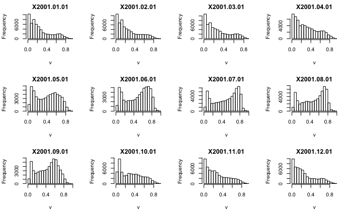

```r
hist(monthly_2001)
```

### Question 3(f)

Plot the NDVI map of July 2000; click any location with data on the map and retrieve the NDVI time series for all years; plot the NDVI time series of the selected location.

[figure not shown]